# Oral microbial signatures of head and neck cancer patients with diverse longitudinal disease severity patterns

Jiadong Mao, Saritha Kodikara

# Introduction

This document describes the analysis of oral microbial signatures in head and neck cancer patients, focusing on their longitudinal disease severity patterns. The analysis includes nonnegative PCA to derive a well-being score, clustering of patient curves, and linear mixed models to identify significant microbial features associated with disease severity.

```r
# Load required packages
suppressPackageStartupMessages(library(PhiSpace))
suppressPackageStartupMessages(library(ggplot2))
suppressPackageStartupMessages(library(dplyr))
suppressPackageStartupMessages(library(tidyr))
suppressPackageStartupMessages(library(magrittr))
suppressPackageStartupMessages(library(ggpubr))
suppressPackageStartupMessages(library(qs)) # quick read and write of R objects
suppressPackageStartupMessages(library(ComplexHeatmap))
suppressPackageStartupMessages(library(seriation))
suppressPackageStartupMessages(library(cluster))
suppressPackageStartupMessages(library(factoextra))
suppressPackageStartupMessages(library(nlme))
suppressPackageStartupMessages(library(circlize))
suppressPackageStartupMessages(library(rcartocolor))
suppressPackageStartupMessages(library(tibble))
suppressPackageStartupMessages(library(PLSKO))
# Load custom functions
source("0.utils.R")
```

# Load data

```r
metaDat <- read.csv(
  paste0("data_filtered/meta_filtered.csv"), row.names = 1
)
metaDat <- metaDat %>%
  dplyr::select(
    c(id, distress:teeth, timepoint)
  )
```

# Calibrated OM score summarising all relevant symptoms.

Only two symptoms had missing values (i.e. taste, distress), so we impute them with the mean of the respective column. We first double-centered the data. That is, we first row-center $X$ and then column-center it so that the double-centered version has zero row means and column means. We conducted the row-centering to the usually column-centering, so that different patients’ ratings at different time points were more comparable.

```r
X <- metaDat %>% dplyr::select(distress:teeth) %>% as.matrix()
for(icol in which(colSums(is.na(X)) > 0)){
  icolVals <- X[,icol]
  X[is.na(icolVals), icol] <- mean(icolVals, na.rm = T)
}
sum(is.na(X))
```

```
## [1] 0
```

```r
Xcent <- PhiSpace::doubleCent(X)
```

To summarize patients’ symptom ratings, we conducted non-negative sparse principal component analysis (NSPCA) of the double-centered version of $X$. We used NSPCA instead of conventional PCA since NSPCA ensures that the principal component (PC) loadings to be nonnegative and sparse, which provides more biological interpretability.

```r
# perform non-negative sparse PCA
npcaRes0 <- nsprcomp::nsprcomp(Xcent, center = F, nneg = T)
npcaRes <- list(
  scores = npcaRes0$x, loadings = npcaRes0$rotation
)
```

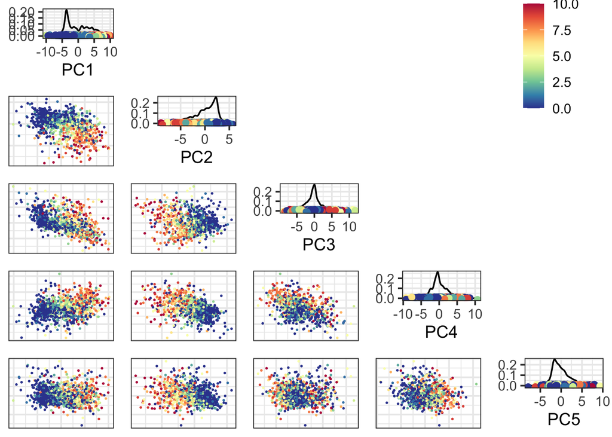

```r
# Visualise the results
PhiSpace::matrixPlot(npcaRes$scores, comp_idx = 1:5, colBy = metaDat$mucositis, compName = "PC", returnPlotList = F)
```

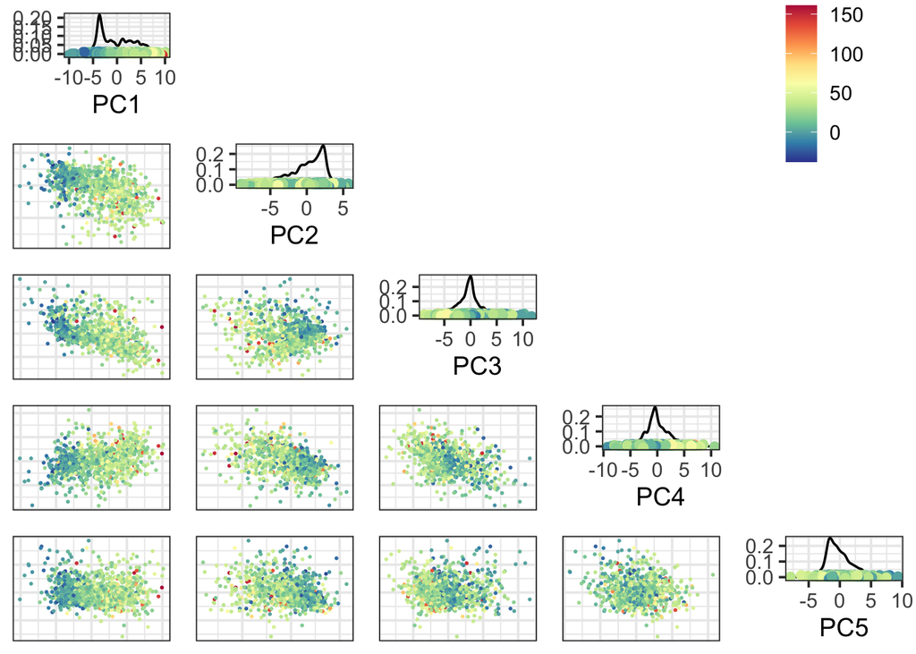

```r
PhiSpace::matrixPlot(npcaRes$scores, comp_idx = 1:5, colBy = metaDat$timepoint, compName = "PC", returnPlotList = F)
```

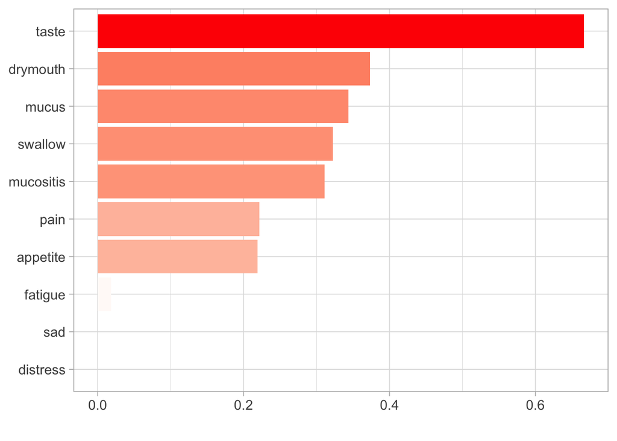

```r
PhiSpace::loadBarplot(npcaRes$loadings, comp = "PC1", nfeat = 10)
```

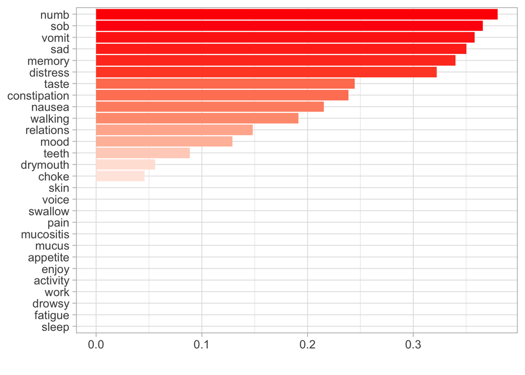

```r
PhiSpace::loadBarplot(npcaRes$loadings, comp = "PC2")
```

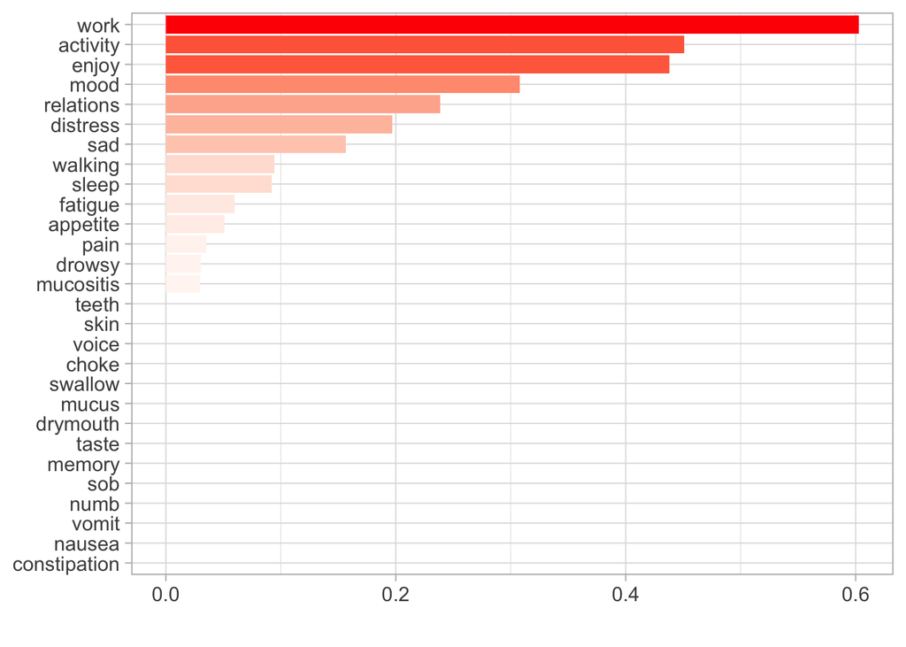

```r
PhiSpace::loadBarplot(npcaRes$loadings, comp = "PC3")
```

```r
# Save the figures for paper
p <- PhiSpace::matrixPlot(
  npcaRes$scores, comp_idx = 1:2, colBy = metaDat$mucositis, compName = "PC",
  returnPlotList = F, pointSize = 1, fsize = 7, legendTitle = ""
)
png(
  paste0("figs/P12_legend.png"),
  width = 2, height = 0.5, units = "in", res = 300
)
op <- par(mar = rep(0, 4))
suppressWarnings(grid::grid.draw(get_legend(p + theme(legend.position = "top"))))
par(op)
dev.off()
```

```r
ggsave(
  paste0("figs/PC12.png"), p + theme(legend.position = "none"), width = 3, height = 2.5
)
p <- PhiSpace::matrixPlot(
  npcaRes$scores, comp_idx = 1, colBy = metaDat$mucositis, compName = "PC",
  returnPlotList = F, pointSize = 1, fsize = 7, legendTitle = ""
)
ggsave(
  paste0("figs/P1.png"), p + theme(legend.position = "none"), width = 3, height = 1.5
)
p <- PhiSpace::loadBarplot(npcaRes$loadings, comp = "PC1", nfeat = 8, fsize = 8)
ggsave(
  paste0("figs/P1_load.png"), p, width = 2.5, height = 3
)
```

```r
metaDat[,"OMscore_calib"] <- npcaRes$scores[,"PC1"]
```

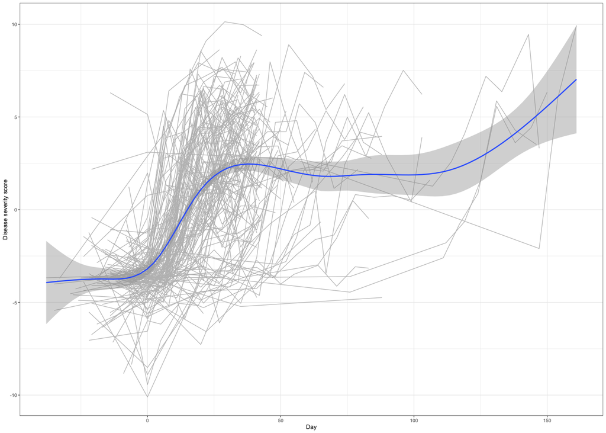

```r
# Visualise the calibrated OM score
metaDat <- metaDat %>% distinct(id, timepoint, .keep_all = TRUE)
ggplot(metaDat, aes(x = timepoint, y = OMscore_calib)) +
  geom_line(aes(group = id), colour = "gray") +
  geom_smooth() +
  labs(x = "Day", y = "Disease severity score") +
  theme_bw(base_size = 5)
```

```r
ggsave("figs/allCurves.png", width = 3, height = 2.5)
```

# Identifying patient groups according to calibrated OM score.

For each patient at their respective observational time points, we used a functional data analysis approach to group the patients according to the longitudinal patterns of their calibrated OM scores.

For the $i$th patient we linearly interpolated the patient’s observed calibrated OM scores at discrete time points to obtain the patient’s calibrated OM score function as $f_i(t)$ for $t\in[\tau_i, T_i]$, where $\tau_i$ and $T_i$ the minimum (baseline) and maximum (discharge) time points of patient $i$. We avoided extrapolating $f_i$ outside its observational time range to retain the original baseline and discharge time points of patients.

```r
# Interpolate calibrated OM scores at discrete time points
timeGrid <- seq(
  min(metaDat$timepoint), max(metaDat$timepoint), 0.5
)
metaList <- split(metaDat, ~id)
interpVals <- lapply(
  1:length(metaList),
  function(ii){
    subDF <- metaList[[ii]]
    modPred <- approx(
      x = subDF$timepoint, y = subDF[,"OMscore_calib"], xout = timeGrid,
    )
    return(modPred)
  }
) %>% `names<-`(names(metaList))
X <- sapply(
  interpVals, function(x) x$y
) %>% t()
```

We then calculated the pairwise distances between the patient’s calibrated OM score functions and found the number of clusters to be $3$ based on the gap statistic.

```r
distM <- distMiss(X)
X2clust <- as.matrix(distM)

#number of clusters according to Gap statistics
set.seed(8790)
#gap_stat <- clusGap(X2clust, hcut, K.max=10, B = 100)
#fviz_nbclust(X2clust, method = "gap_stat", FUN=hcut)
```

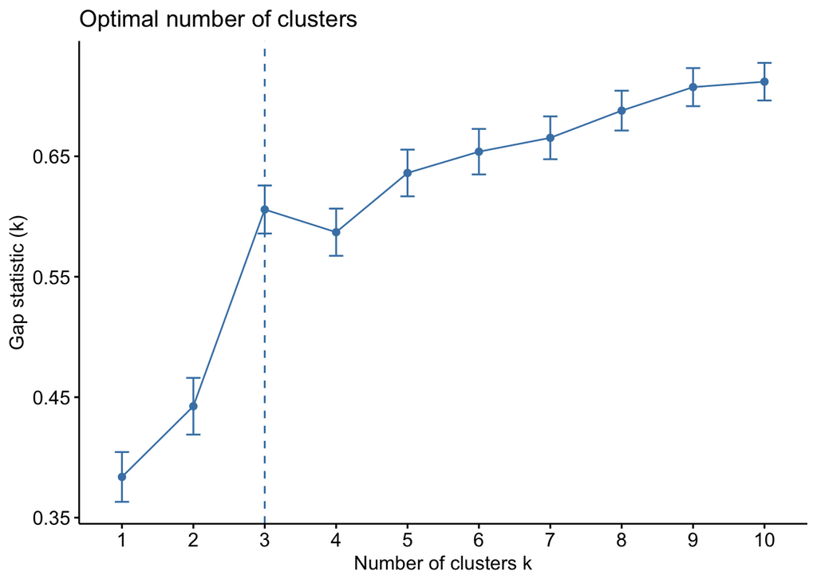

```r
# From the plot, we choose k = 3

fviz_nbclust(X2clust, method = "gap_stat", FUN=hcut)
```

```r
ggsave("figs/gap_stat.png", width = 4, height = 3)
```

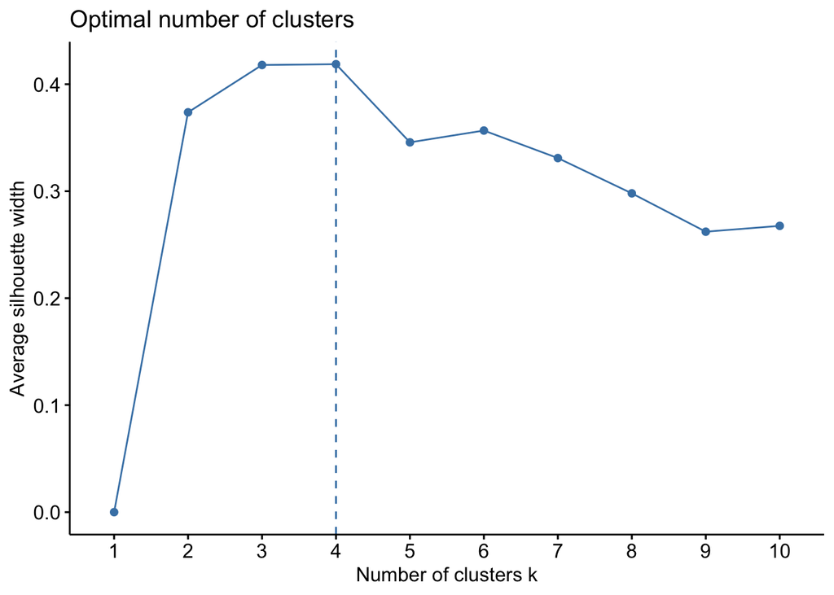

```r
fviz_nbclust(X2clust, method = "silhouette", FUN=hcut)
```

```r
ggsave("figs/silhouette_stat.png", width = 4, height = 3)
```

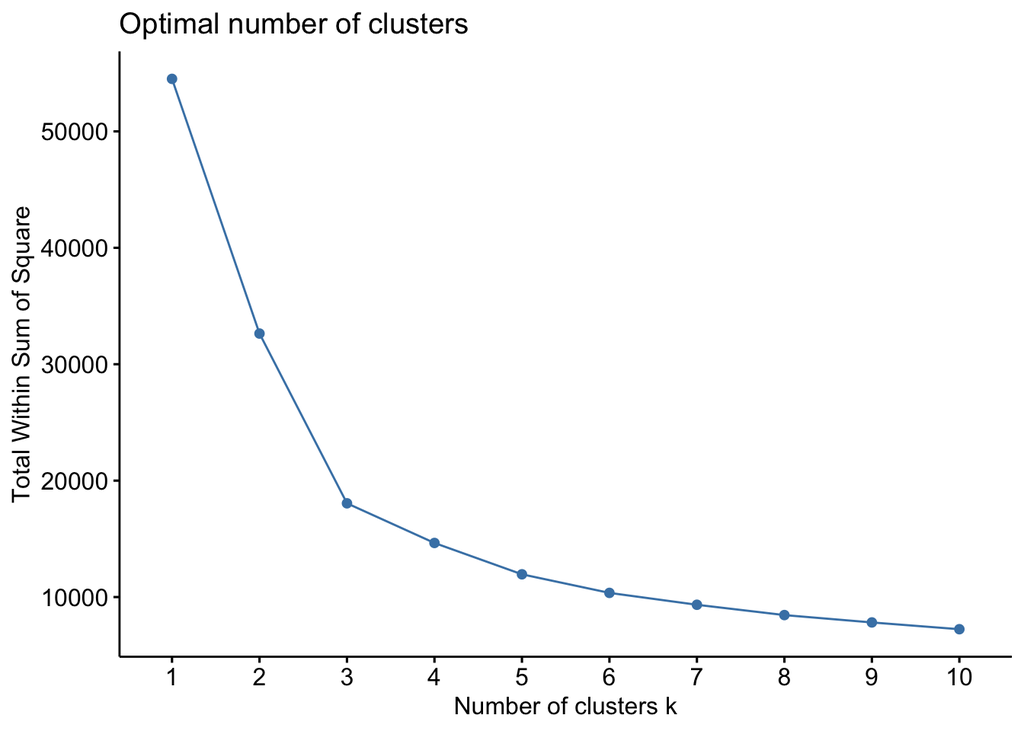

```r
fviz_nbclust(X2clust, method = "wss", FUN=hcut)
```

```r
ggsave("figs/wss_stat.png", width = 4, height = 3)
```

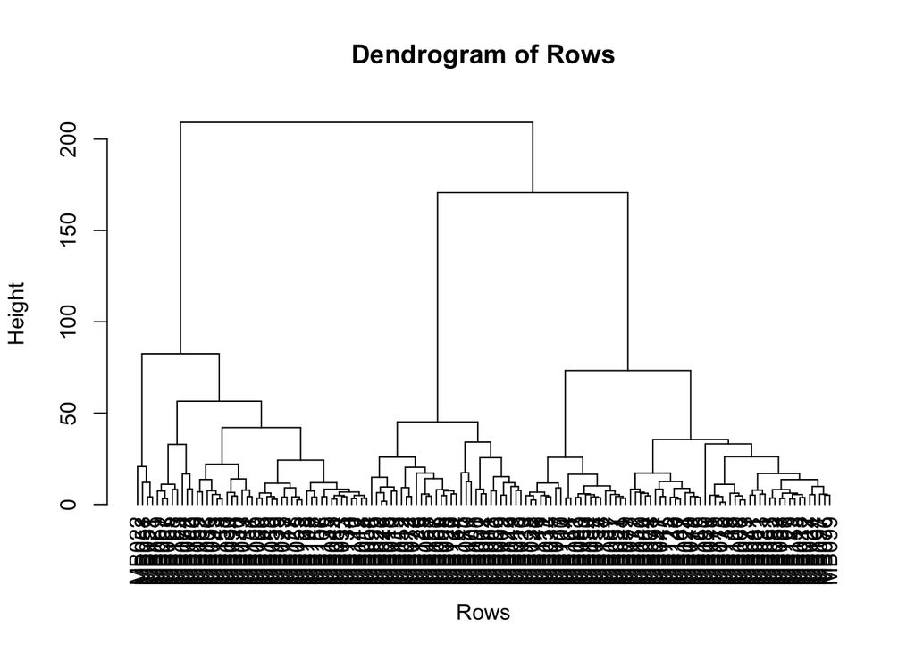

```r
#visualise the calibrated OM score trajectories for each cluster
set.seed(8475)
hc <- hclust(dist(X2clust), method = "ward.D2")
plot(as.dendrogram(hc), main = "Dendrogram of Rows", xlab = "Rows", ylab = "Height")
```

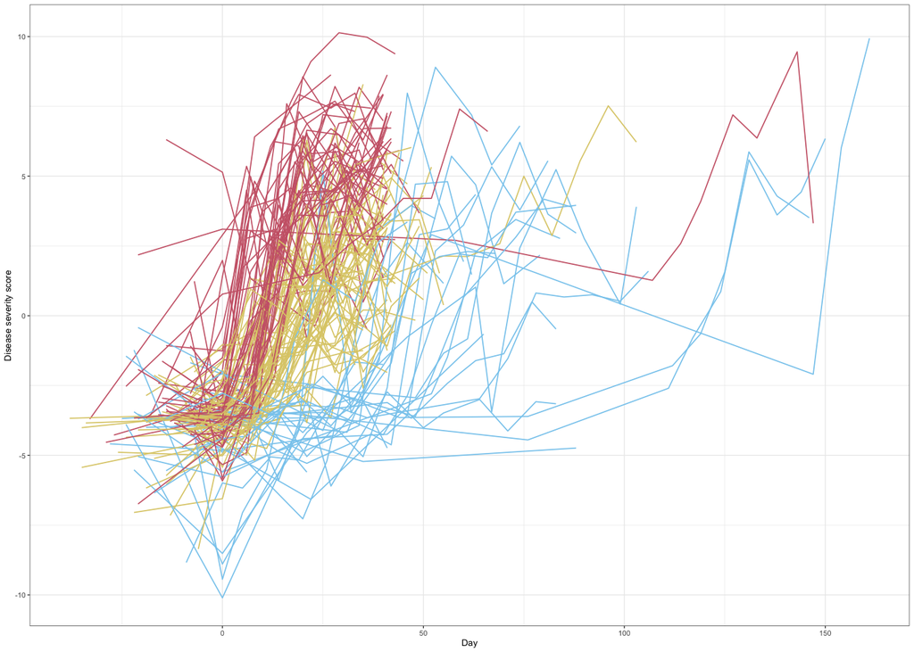

```r
k <- 3
clusters <- hcut(X2clust, k = k)$cluster
df <- X2clust %>% as.data.frame() %>% mutate(id = rownames(X2clust), cluster = as.factor(clusters))
metaDat_c <- merge(metaDat, df[,c("id", "cluster")], by = "id")
ggplot(metaDat_c, aes(x = timepoint, y = OMscore_calib, color = cluster, group = id)) +
    geom_line(linewidth = 0.3) +
    labs( x = "Day", y = "Disease severity score") +
    theme_bw(base_size = 5) +
    theme(
        legend.title = element_text(face = "bold", size=9),
        legend.text=element_text(size=8),
        legend.position="none"
    ) +
    scale_color_manual(labels = c("1 (n=31)", "2 (n=47)", "3 (n=62)"),
                       values = carto_pal(n=5, "Safe"))
```

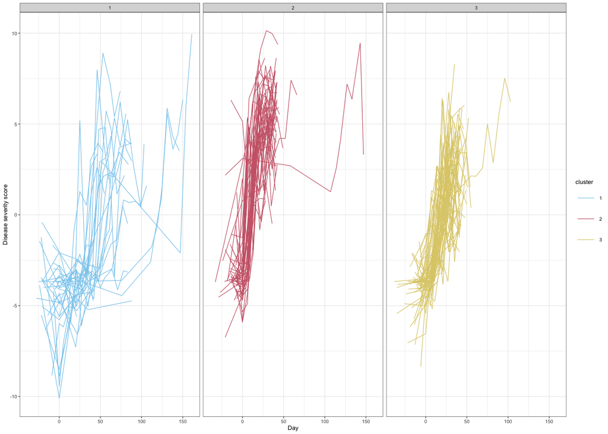

```r
ggsave("figs/curvesCluster.png", width = 3, height = 2.5)
ggplot(metaDat_c, aes(x = timepoint, y = OMscore_calib, color = cluster, group = id)) +
  geom_line() +
  labs( x = "Day", y = "Disease severity score") +
  theme_bw(base_size = 5)+
  facet_wrap(~ cluster)+
    scale_color_manual(values = carto_pal(n=5, "Safe"))
```

```r
metaDat_c%>% dplyr::select(id, cluster) %>% unique()%>%dplyr::select(cluster)%>%table()
```

```
## cluster
##  1  2  3
## 31 47 62
```